# Shooting Incidents in NYC Spiked in 2020

Michael Bailey

7/15/2021

## Libraries

I will be using the `tidyverse` package for data import, manipulation, and plotting, the `lubridate` package for handling dates, the `viridis` package for plot colors, and the `forecast` package for analyzing time series data.

```r
library(tidyverse)
library(lubridate)
library(viridis)
library(forecast)
```

## Import

```r
rawData <- read_csv("https://data.cityofnewyork.us/api/views/833y-fsy8/rows.csv?accessType=DOWNLOAD",
                col_types = cols(
                  INCIDENT_KEY = col_double(),
                  OCCUR_DATE = col_date(format = "%m/%d/%Y"),
                  OCCUR_TIME = col_time(format = "%H:%M:%S"),
                  BORO = col_factor(),
                  PRECINCT = col_factor(),
                  JURISDICTION_CODE = col_double(),
                  LOCATION_DESC = col_factor(),
                  STATISTICAL_MURDER_FLAG = col_logical(),
                  PERP_AGE_GROUP = col_factor(),
                  PERP_SEX = col_factor(),
                  PERP_RACE = col_factor(),
                  VIC_AGE_GROUP = col_factor(),
                  VIC_SEX = col_factor(),
                  VIC_RACE = col_factor(),
                  X_COORD_CD = col_number(),
                  Y_COORD_CD = col_number(),
                  Latitude = col_double(),
                  Longitude = col_double()
                ))
```

## Tidy and Transform

The raw data contains multiple rows for individual incidents as a result of there being multiple perpetrators or victims. The individuals in these groups may not distinguishable by combination of the age, race, and sex information present in the data. This is illustrated in the following example of a single incident.

```r
dupCols <- c("PERP_AGE_GROUP", "PERP_SEX", "PERP_RACE", "VIC_AGE_GROUP", "VIC_SEX", "VIC_RACE", "STATISTICAL_MURDER_FLAG")
rawData %>%
  add_count(INCIDENT_KEY, sort = TRUE) %>%
  slice_head(n = 18) %>%
  select(all_of(dupCols))
```

```
## # A tibble: 18 x 7
##    PERP_AGE_GROUP PERP_SEX PERP_RACE      VIC_AGE_GROUP VIC_SEX VIC_RACE
##    <fct>          <fct>    <fct>          <fct>         <fct>   <fct>
##  1 18-24          M        WHITE HISPANIC 45-64         F       WHITE HISPANIC
##  2 25-44          M        BLACK          45-64         F       WHITE HISPANIC
##  3 18-24          M        WHITE HISPANIC 45-64         F       WHITE HISPANIC
##  4 18-24          M        WHITE HISPANIC 45-64         M       WHITE HISPANIC
##  5 25-44          M        BLACK          45-64         M       WHITE HISPANIC
##  6 18-24          M        WHITE HISPANIC 18-24         M       BLACK HISPANIC
##  7 18-24          M        BLACK          45-64         F       WHITE HISPANIC
##  8 25-44          M        BLACK          18-24         M       BLACK HISPANIC
##  9 18-24          M        BLACK          45-64         F       WHITE HISPANIC
## 10 25-44          M        BLACK          45-64         F       WHITE HISPANIC
## 11 18-24          M        BLACK          18-24         M       BLACK HISPANIC
## 12 25-44          M        BLACK          45-64         M       WHITE HISPANIC
## 13 18-24          M        BLACK          18-24         M       BLACK HISPANIC
## 14 18-24          M        WHITE HISPANIC 18-24         M       BLACK HISPANIC
## 15 18-24          M        BLACK          45-64         M       WHITE HISPANIC
## 16 25-44          M        BLACK          18-24         M       BLACK HISPANIC
## 17 18-24          M        BLACK          45-64         M       WHITE HISPANIC
## 18 18-24          M        WHITE HISPANIC 45-64         M       WHITE HISPANIC
## # ... with 1 more variable: STATISTICAL_MURDER_FLAG <lgl>
```

Clearly multiple perpetrators and victims were involved, but it is not possible to say how many. The same perpetrator may be represented on multiple rows to allow for multiple victims (or vice versa), but it is also possible to have two perpetrators with the same demographics. I will limit my analysis to the frequency of shooting incidents over time, so I will discard these columns and keep only the information to uniquely identify and date each occurrence. Using `summary`, we see that there are no missing values in these columns.

```r
data <- rawData %>%
  select(INCIDENT_KEY, OCCUR_DATE) %>%
  distinct() %>%
  arrange(OCCUR_DATE)
summary(data)
```

```
##   INCIDENT_KEY         OCCUR_DATE
##  Min.   :  9953245   Min.   :2006-01-01
##  1st Qu.: 57282439   1st Qu.:2009-02-13
##  Median : 84347263   Median :2012-04-22
##  Mean   :103127851   Mean   :2012-10-30
##  3rd Qu.:152011156   3rd Qu.:2016-04-09
##  Max.   :222473262   Max.   :2020-12-31
```

I will create additional columns for the month, year, and calendar month of the occurrences, and summarize the data by counting the number of monthly incidents.

```r
data <- data %>%
  mutate(OCCUR_MONTH = month(OCCUR_DATE, label = TRUE),
         OCCUR_DATE_MONTH = floor_date(OCCUR_DATE, "month"),
         OCCUR_YEAR = year(OCCUR_DATE))

monthlyData <- data %>%
  count(OCCUR_DATE_MONTH, OCCUR_MONTH, OCCUR_YEAR, name = "OCCUR_MONTH_COUNT")
```

## Analysis

A cursory inspection of the frequency of incidents over time reveals a seasonal pattern. More shootings appear to be reported in summer than in winter. This is shown below by plotting the 15 years of monthly data by calendar month.

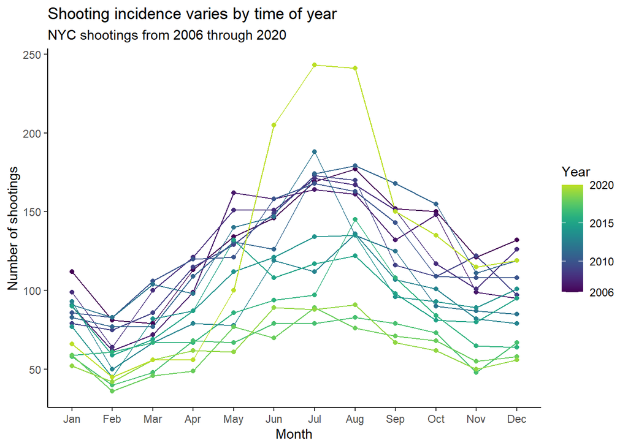

```r
monthlyData %>%
  ggplot(aes(x = OCCUR_MONTH, y = OCCUR_MONTH_COUNT, group = OCCUR_YEAR, color = OCCUR_YEAR)) +
  geom_line() +
  geom_point() +
  scale_color_viridis(end = 0.9, breaks = c(2006,2010,2015,2020)) +
  theme_classic() +
  labs(title = "Shooting incidence varies by time of year",
       subtitle = "NYC shootings from 2006 through 2020",
       x = "Month",
       y = "Number of shootings",
       color = "Year")
```

To separate the seasonal effects from any underlying trends, I will use Seasonal and Trend decomposition using Loess (STL) (Cleveland et al. 1990) via the `stl` function in the `forecast` package. The function requires a `ts` object, so I will create one from the monthly summary. This method decomposes the data into three components: seasonal, trend, and remainder, using locally weighted regression, or loess, to fit a smooth curve to the data. The seasonal component represents a pattern in the data that recurs over a fixed period of time, one year in this case, whereas the trend describes the long-term, non-seasonal changes in the data. The remainder is simply the residual of model, representing the variation in the data that is not accounted for by the seasonal and trend components. The relationship at each time point $t$ between the actual data $A_t$, trend $T_t$, seasonal $S_t$, and remainder $R_t$ is:

$$A_t = T_t+S_t+R_t$$

The plot of the decomposed data below further clarifies the seasonality of the data. The rate of shootings follows an annual cycle of higher rates in the summer and lower rates in the winter. Furthermore, there was a downward trend in the number of shooting incidents from 2006 until 2020, when there was a large spike.

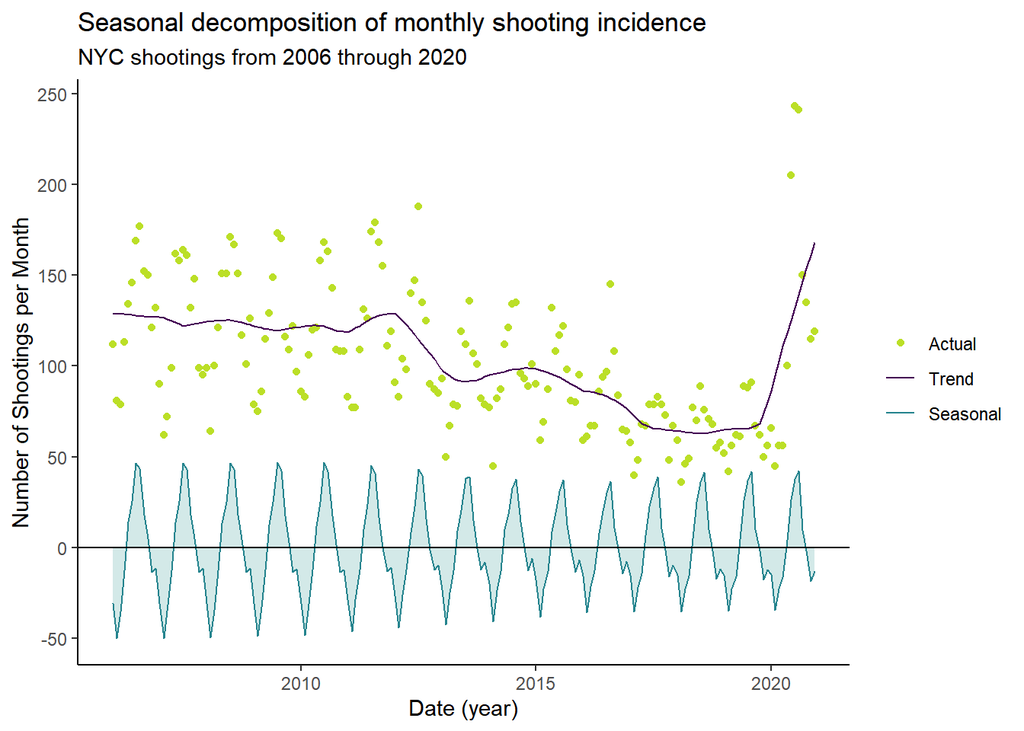

```r
plotData <- ts(monthlyData$OCCUR_MONTH_COUNT, frequency = 12, start = c(2006, 1)) %>%
  stl(s.window = 11) %>%
  as_tibble(x = .[[1]]) %>%
  bind_cols(monthlyData, .) %>%
  pivot_longer(cols = all_of(c("OCCUR_MONTH_COUNT","seasonal","trend","remainder"))) %>%
  filter(name != "remainder")

ggplot(plotData, aes(x = OCCUR_DATE_MONTH, y = value, color = name)) +
  geom_point(data = filter(plotData, name == "OCCUR_MONTH_COUNT")) +
  geom_line(data = filter(plotData, name == "trend")) +
  geom_area(data = filter(plotData, name == "seasonal"),
            fill = viridis(3, option = "D", alpha = 0.2)[2],
            show.legend = FALSE) +
  scale_color_viridis(end = 0.9, direction = -1, option = "D",
                      discrete = TRUE,
                      breaks = c("OCCUR_MONTH_COUNT", "trend", "seasonal"),
                      labels = c("Actual", "Trend", "Seasonal"),
                      guide =
                        guide_legend(title = NULL,
                                     override.aes = list(shape = c(19,NA,NA),
                                                         linetype = c(0,1,1))))+
  labs(title = "Seasonal decomposition of monthly shooting incidence",
       subtitle = "NYC shootings from 2006 through 2020",
       x = "Date (year)", y = "Number of Shootings per Month") +
  geom_hline(yintercept = 0) +
  scale_y_continuous(n.breaks = 8) +
  theme_classic()
```

## Conclusion

My analysis shows that the frequency of shooting incidents in NYC was decreasing from 2006 to 2019, followed by a surge in the summer of 2020. This effect is too large to be attributed to the regular increase observed in previous summers. Indeed, the increase was reported in the media (Watkins 2020), and attributed to various causes by different groups. NYC mayor Bill de Blasio and police commissioner, Dermot F. Shea, have blamed the pandemic, George Floyd protests, and cash bail reform in the state (Feuer 2020). Future work is needed to evaluate these claims, and discover true causes to the marked increase in shootings.

The limited scope of this analysis should somewhat insulate it from bias. Still, the data is provided by the NYPD, a clear stakeholder in any conclusions. Additionally, the data must be influenced by policing practices overtime, i.e. more shooting incidents will appear in the data when/where there is more enforcement by police. Finally, I am writing this from the perspective of an outsider, who hears about what happens in NYC largely through national media. I tried to avoid drawing conclusions that extend beyond the scope of this analysis.

## References

Cleveland, Robert B., William S. Cleveland, Jean. E. McRae, and Irma Terpenning. 1990. “STL: A Seasonal-Trend Decomposition Procedure.” *Journal of Official Statistics* 6 (1): 3–73. https://www.wessa.net/download/stl.pdf.

Feuer, Alan. 2020. “The Mayor Blames the Virus for Shootings. Here’s What Crime Data Shows.” *The New York Times*, August. https://www.nytimes.com/2020/08/04/nyregion/nyc-shootings-coronavirus.html.

Watkins, Ali. 2020. “Violent Year in New York and Across U.s. As Pandemic Fuels Crime Spike.” *The New York Times*, December. https://www.nytimes.com/2020/12/29/nyregion/nyc-2020-crime-covid.html.